# Activity: Nuclear Reactors

Abdulaziz Bokijonov

```r
library(tidyverse)
```

## Scrape the Data

```r
#My code here....
library(rvest)

page <- "https://en.wikipedia.org/wiki/List_of_commercial_nuclear_reactors"
tableList <- page %>%
  read_html() %>%
  html_nodes(css = "table") %>%
  html_table(fill = TRUE)

# Remove null columns
Japan <- tableList[[21]][1:9]
# Rename columns
Japan <-
  Japan %>%
  rename(name = Plantname,
         reactor = `UnitNo.`,
         type = Type,
         model = Model,
         status = Status,
         netMW = `Capacity(MW)`,
         construction = `Beginbuilding`,
         operation = `Commercialoperation`,
         closure = Closed)
# Remove the first row
Japan <- Japan[-1,]
Japan
```

| name | reactor | type | model | status | netMW | construction | operation | closure |
| --- | --- | --- | --- | --- | --- | --- | --- | --- |
| Fukushima Daiichi | 1 | BWR | BWR-3 | Inoperable | 439 | 25 Jul 1967 | 26 Mar 1971 | 19 May 2011 |
| Fukushima Daiichi | 2 | BWR | BWR-4 | Inoperable | 760 | 9 Jun 1969 | 18 Jul 1974 | 19 May 2011 |
| Fukushima Daiichi | 3 | BWR | BWR-4 | Inoperable | 760 | 28 Dec 1970 | 27 Mar 1976 | 19 May 2011 |
| Fukushima Daiichi | 4 | BWR | BWR-4 | Inoperable | 760 | 12 Feb 1973 | 12 Oct 1978 | 19 May 2011 |
| Fukushima Daiichi | 5 | BWR | BWR-4 | Shut down | 760 | 22 May 1972 | 18 Apr 1978 | 17 Dec 2013 |
| Fukushima Daiichi | 6 | BWR | BWR-5 | Shut down | 1067 | 26 Oct 1973 | 24 Oct 1979 | 17 Dec 2013 |
| Fukushima Daini | 1 | BWR | BWR-5 | Shut down | 1067 | 16 Mar 1976 | 20 Apr 1982 | 30 Sep 2019 |
| Fukushima Daini | 2 | BWR | BWR-5 | Shut down | 1067 | 25 May 1979 | 3 Feb 1984 | 30 Sep 2019 |
| Fukushima Daini | 3 | BWR | BWR-5 | Shut down | 1067 | 23 Mar 1981 | 21 Jun 1985 | 30 Sep 2019 |
| Fukushima Daini | 4 | BWR | BWR-5 | Shut down | 1067 | 28 May 1981 | 25 Aug 1987 | 30 Sep 2019 |

[output cut: 58 more lines]

Parsing the raw table created 9 more unnecessary empty columns and one row that contained column lables. Thus, I had to remove those 9 columns and one row that had column labels.

## Your turn: In what ways is the table tidy? How is it not tidy? What’s different about it from a tidy table?

Columns like plantname has names of plants separated by space, which is not tidy. Also, some cells do not have any data.

## Your Turn: Plot Net Generation Capacity vs Construction Date

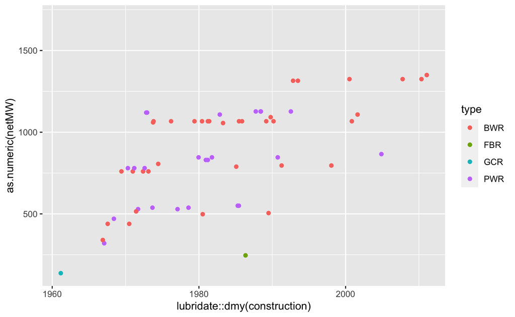

```r
#my code here
Japan %>%
  ggplot(aes(x = lubridate::dmy(construction), y = as.numeric(netMW), color=type)) +
  geom_point()
```

In general, the newer are the reactors, the more net generation capacity it has. When it comes to the type, BWR seems to outperform other types.

## Your Turn: Scrape & Clean China Data (then merge with Japan)

```r
#my code here...
library(gdata)
# Remove null columns
China <- tableList[[10]][1:9]
# Rename columns
China <-
  China %>%
  rename(name = Plantname,
         reactor = `UnitNo.`,
         type = Type,
         model = Model,
         status = Status,
         netMW = `Capacity(MW)`,
         construction = `Beginbuilding`,
         operation = `Commercialoperation`,
         closure = Closed)
# Remove the first two rows
China <- China[-1,]
China <- China[-1,]
#full outer join
JapanChina <- combine(China, Japan)
JapanChina
```

| name | reactor | type | model | status | netMW | construction | operation | closure | source |
| --- | --- | --- | --- | --- | --- | --- | --- | --- | --- |
| Changjiang | I-1 | PWR | CNP-600 | Operational | 601 | 25 Apr 2010 | 25 Dec 2015 |  | China |
| Changjiang | I-2 | PWR | CNP-600 | Operational | 601 | 21 Nov 2010 | 20 Jun 2016 |  | China |
| Changjiang | I-3[21] | PWR | Hualong One | Under construction | 1200 | 31 Mar 2021[22] |  |  | China |
| Changjiang | I-4[21] | PWR | Hualong One | Under construction | 1200 | 31 Mar 2021[22] |  |  | China |
| Changjiang | II-1 | PWR | ACP-100 | Under construction | 100 | 13 Jul 2021 |  |  | China |
| Changjiang | II-2 | PWR | ACP-100 | Planned | 100 |  |  |  | China |
| Daya Bay | 1 | PWR | M-310 | Operational | 944 | 7 Aug 1987 | 1 Feb 1994 |  | China |
| Daya Bay | 2 | PWR | M-310 | Operational | 944 | 7 Apr 1988 | 6 May 1994 |  | China |
| Fangchenggang | 1 | PWR | CPR-1000 | Operational | 1000 | 30 Jul 2010 | 25 Oct 2015 |  | China |
| Fangchenggang | 2 | PWR | CPR-1000 | Operational | 1000 | 23 Dec 2010 | 15 Jul 2016 |  | China |

[output cut: 168 more lines]

After reading some post on stackoverflow, I have decided to use combine function from gdata library, because it automatically adds the source of data to the combined dataset.

## Your Turn: Reconstruct Info Graphic of Japan Reactors (or other country of interest)

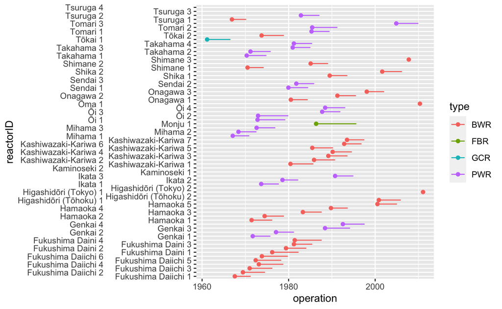

```r
#My code here
toGraph <- Japan %>%
  group_by(name) %>%
  mutate(reactorID = paste(name, row_number()))
toGraph %>%
  mutate(status_change = !is.na(status)) %>%
  ggplot(aes(x = lubridate::dmy(construction), y = reactorID, color=type)) +
  geom_segment(aes(x = lubridate::dmy(construction), xend=lubridate::dmy(operation), yend=reactorID)) +
  scale_y_discrete(guide = guide_axis(n.dodge=2)) +
  labs(y = "reactorID", x = "operation")  +
  geom_point()
```

For this graph, because the y axis contained to many lables and they were overlaping each other, I used scale_y_discrete function to solve for that